# Hurricane Melissa (2025): Rapid Report

Lincole Jiang, Majd Abid, Lawrence Chillrud, G. Brooke Anderson, Robbie M. Parks

2026-04-16

## Summary

**Data status:** Best-track / reanalyzed (main)

*Hurricane Melissa* (2025) was active from 2025-10-21 06:00:00 to 2025-11-01 06:00:00 UTC. Based on IBTrACS data obtained 04/16/2026, 6,764,435 people experienced tropical cyclone-force (>= 17.49 m/s) winds and 2,695,529 people experienced hurricane-force (>= 32.90 m/s) winds across Bahamas, Cuba, Jamaica. 76,409.07 people experienced Category 5 (>= 70.5 m/s) winds.

Table 1: Population exposed by country and storm intensity

| Country | Population exposed (tropical cyclone-force) | Population exposed (hurricane-force) | Population exposed (category 5) |
| --- | --- | --- | --- |
| Cuba | 3,936,507 | 1,529,899 | 0 |
| Jamaica | 2,814,476 | 1,165,631 | 76,409 |
| Bahamas | 13,452 | 0 | 0 |

When accounting for total population, the table below shows the percentage of each country’s population exposed.

Table 2: Percentage of total population exposed by country and storm intensity

| Country | % Population exposed (tropical cyclone-force) | % Population exposed (hurricane-force) | % Population exposed (category 5) |
| --- | --- | --- | --- |
| Cuba | 34.9 | 13.6 | 0.0 |
| Jamaica | 100.0 | 41.4 | 2.7 |
| Bahamas | 3.4 | 0.0 | 0.0 |

The spatial extent of the impacts is illustrated in Figure 1, which maps exposure by wind intensity threshold at the second administrative unit (ADM2) level along with the storm track of Melissa.

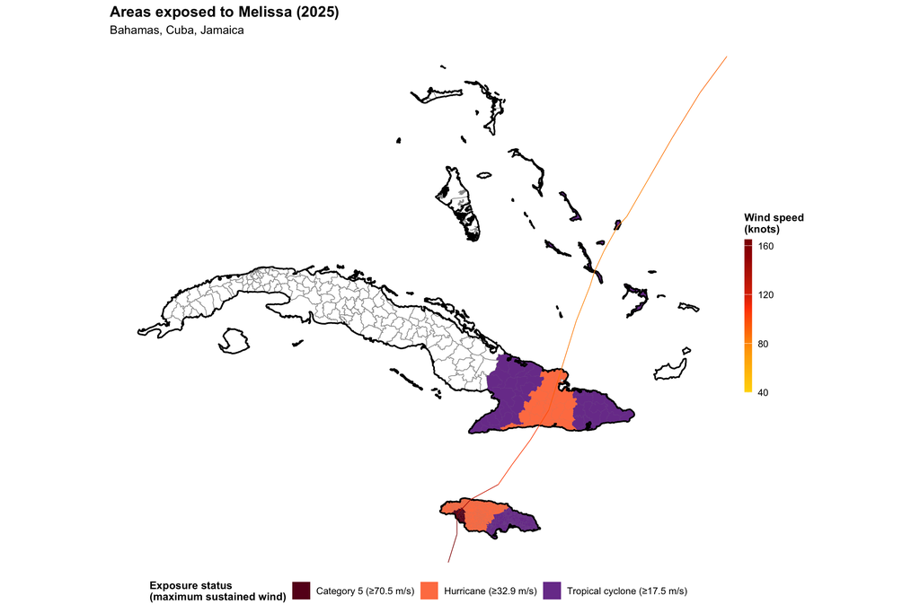

Figure 1: Spatial distribution of exposure

## Characterizing exposed areas

Figure 2 shows the distribution of relative deprivation (measured by population-weighted GRDI, aggregated to ADM2 level) and population for each exposed area, categorized by exposure status.

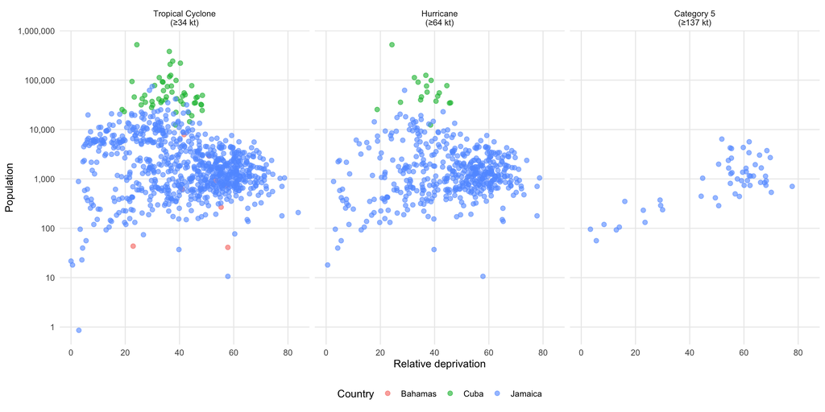

Figure 2: Socioeconomic and population distribution of exposed areas

Furthermore, we list the top areas affected (categorized by exposure status) with the most population:

|  | Area | Country | Population | Relative deprivation |
| --- | --- | --- | --- | --- |
| 1 | Santiago de Cuba | Cuba | 522,470 | Moderately low |
| 2 | Holguín | Cuba | 381,623 | Moderately high |
| 3 | Bayamo | Cuba | 243,035 | Moderately high |
| 4 | Guantánamo | Cuba | 221,068 | Moderately high |
| 5 | Las Tunas | Cuba | 209,752 | Moderately high |
| 6 | Palma Soriano | Cuba | 125,256 | Moderately high |
| 7 | Manzanillo | Cuba | 117,281 | Moderately high |
| 8 | Contramaestre | Cuba | 112,772 | Moderately low |
| 9 | Mayarí | Cuba | 98,844 | Moderately high |
| 10 | Baracoa | Cuba | 94,112 | Moderately low |

[output cut: 835 more lines]

|  | Area | Country | Population | Relative deprivation |
| --- | --- | --- | --- | --- |
| 1 | Santiago de Cuba | Cuba | 522,470 | Moderately low |
| 2 | Palma Soriano | Cuba | 125,256 | Moderately high |
| 3 | Contramaestre | Cuba | 112,772 | Moderately low |
| 4 | Mayarí | Cuba | 98,844 | Moderately high |
| 5 | Songo - La Maya | Cuba | 91,139 | Moderately high |
| 6 | Banes | Cuba | 77,349 | Moderately high |
| 7 | San Luis | Cuba | 76,056 | Moderately high |
| 8 | Mandeville Proper | Jamaica | 62,344 | Moderately low |
| 9 | Rafael Freyre | Cuba | 57,307 | Moderately high |
| 10 | Jiguaní | Cuba | 55,268 | Moderately high |

[output cut: 478 more lines]

|  | Area | Country | Population | Relative deprivation |
| --- | --- | --- | --- | --- |
| 1 | Black River | Jamaica | 6,407 | High |
| 2 | Whitehouse | Jamaica | 5,643 | High |
| 3 | Bethel Town | Jamaica | 4,333 | High |
| 4 | Petersfield | Jamaica | 4,257 | High |
| 5 | Smithfield | Jamaica | 4,118 | High |
| 6 | New Market | Jamaica | 3,742 | High |
| 7 | Bluefields | Jamaica | 3,393 | High |
| 8 | Darliston | Jamaica | 3,033 | High |
| 9 | Giddy Hall | Jamaica | 2,703 | High |
| 10 | Brompton | Jamaica | 2,634 | High |

[output cut: 43 more lines]

- Note: GRDI relative deprivation values were classified into quartiles: 0–0.25 (low), 0.25–0.50 (moderately low), 0.50–0.75 (moderately high), 0.75–1.0 (high).